# Part II - Ford GoBike System Data

## by Victor Obi

## Investigation Overview

> Trip count is highest on thursdays with tuesday and wednesday in close second and third respectively. Analysis shows a sharp peak in trip duration after midnight. In otherwords users log in more trip time between 2am and 4am. Customers of all gender logged in more trip time when compared to subscribers of all gender. Female customers logged in more trip time compared to male customers.

## Dataset Overview

> The dataset explores data obtained from the Ford GoBike system data. It contains 183412 rows and 16 columns and shed light on the bikeshare habits of users around greater San Francisco Bay area between feb 2019 and and march 2019. The dataset presented with some data quality issues such as - Start_time and end_time are listed as object datatype duration_sec is measured in seconds user_type, member_gender, bike_share_for_all_trip are listed as object datatype bike_id, start_station_id and end_station_id are listed float and int datatype Age column is missing The above issues were resolved resulting in a dataset fit for exploration.

## Trip Distribution by Day of the Week

> The figure below shows a plot of Trip count by day of the week. Trip count is highest on thursdays with tuesday and wednesday in close second and third respectively. In otherwords, more users are keen to use the bike share services on the aforementioned days. Making more bikes available and ensuring they are properly charged on these days may encourage user satisfaction and by extension revenue.

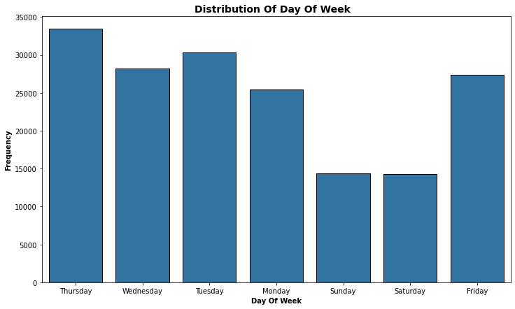

## Hourly Mean of Trip Duration(mins)

> The figure below shows a breakdown of hourly trip duration. Analysis shows a sharp peak in trip duration after midnight. In otherwords users log in more trip time between 2am and 4am. This is followed by a sharp drop which remains stable till 10pm.

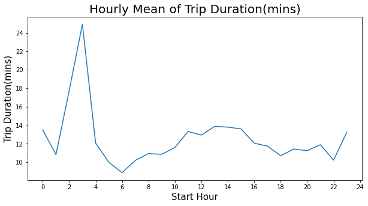

## Plot of Trip Duration by User Type and Gender

> A plot of trip duration by user type and gender shows that customers of all gender logged in more trip time when compared to subscribers of all gender. Female customers logged in more trip time compared to male customers. This is interesting because 74.5% of users are male compared to 23.4% of females.

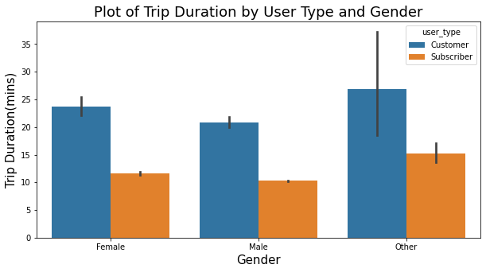